# Neural Network Analysis - Student Dropout Prediction

Early Warning System for Student Dropout Risk

2025-12-14

# Summary

We use neural networks as an **early warning system** to predict whether a student is at risk of **dropping out** (**Dropout vs NotDropout**) based on early academic performance and financial indicators. Here, **NotDropout** means the student is either **still enrolled** or has **graduated**. The goal is not only accuracy, but also **actionability**: the model should highlight which signals (grades, approved courses, tuition status) are most associated with dropout risk.

## Objective

We want our neural network to play the role of an early-warning system: predict **Dropout vs NotDropout** by learning the messy, non-linear patterns hidden in the data.

## Feature Selection

We focus on three feature blocks from the preprocessed dataset:

1. **Early academic performance:** 1st- and 2nd-semester grades plus approved credits showed the highest F-values in our ANOVA screening during preprocessing, making them the strongest predictors of the target variable.
2. **Financial pressure/support:** Tuition fees up to date, debtor status, and scholarship holder indicate whether financial stress may affect the student.
3. **Entry profile:** Admission grade and age at enrollment provide baseline information about the student’s starting point.

## Data Loading & Preprocessing

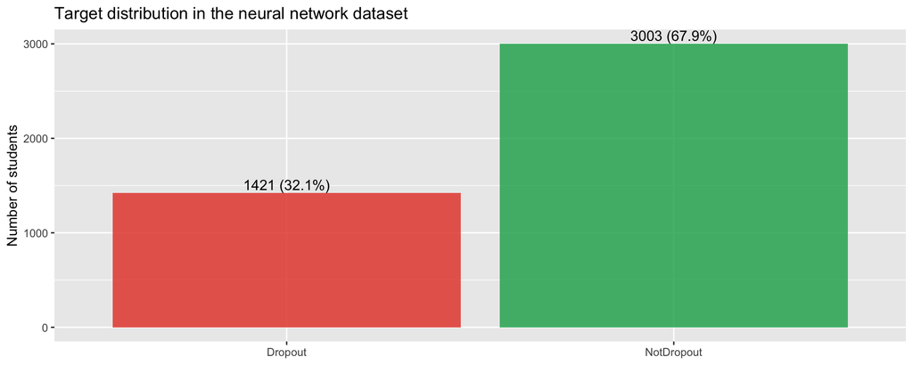

```r
target_counts <- nn_model_data %>%
  count(Target) %>%
  mutate(Percent = n / sum(n) * 100)

ggplot(target_counts, aes(x = Target, y = n, fill = Target)) +
  geom_col(alpha = 0.85) +
  geom_text(aes(label = paste0(n, " (", round(Percent, 1), "%)")), vjust = -0.3, size = 4) +
  scale_fill_manual(values = c("Dropout" = "#E74C3C", "NotDropout" = "#27AE60")) +
  labs(
    title = "Target distribution in the neural network dataset",
    x = NULL,
    y = "Number of students"
  ) +
  theme(legend.position = "none")
```

This modeling subset contains **4424** students after removing missing values. The chart above shows the class balance.

## Train/Test Split

```r
set.seed(123)
train_idx <- createDataPartition(nn_model_data$Target, p = 0.8, list = FALSE) # not using runif(nrow(GermanCredit)) < 0.8 simply to sample ~80% of rows without worrying about class balance
train_nn <- nn_model_data[train_idx, ]
test_nn <- nn_model_data[-train_idx, ]
```

We use an **80/20 split**: training = **3540**, test = **884**.

## Model Training

We train two neural networks to compare Lab 1 and Lab 2 approaches.

### Model A: Single Hidden Layer (Lab 1 - nnet)

Following `ANN_Lab1_GermanCredit_v1.Rmd`, we use `nnet` with one hidden layer and weight decay.

```r
# Model A: nnet with single hidden layer (Lab 1 style)
model_A <- nnet(
  Target ~ .,
  data = train_nn,
  size = 10,        # 10 hidden neurons in one layer
  decay = 0.01,     # Weight decay: small penalty on large weights to prevent overfitting
  maxit = 500,      # Maximum training iterations
  trace = FALSE     # Suppress training progress output
)
```

### Model B: Three Hidden Layers (Lab 2 - neuralnet)

Following `ANN_Lab2_Iris_v1.Rmd`, we use `neuralnet` with a deeper architecture using **three hidden layers**. This requires numeric inputs and numeric output columns, so we build 0/1 columns for our binary target.

In this run, Model B uses a **2-5-2** hidden-layer setup (2 neurons → 5 neurons → 2 neurons). We also set `threshold = 0.8` mainly to keep runtime manageable while we debug and iterate. A **larger** threshold usually stops earlier (faster), but it can also stop before the model has learned enough.

```r
# One-hot encode predictors for neuralnet (Lab 2 approach)
dummies <- dummyVars(Target ~ ., data = train_nn)
train_matrix <- as.data.frame(predict(dummies, newdata = train_nn))
test_matrix <- as.data.frame(predict(dummies, newdata = test_nn))

# Create dummy columns for binary target (neuralnet needs numeric output)
train_matrix$Target_Dropout <- as.numeric(train_nn$Target == "Dropout")
train_matrix$Target_NotDropout <- as.numeric(train_nn$Target == "NotDropout")

# Build formula: output columns ~ input columns
input_names <- names(train_matrix)[!grepl("Target", names(train_matrix))]
output_names <- c("Target_Dropout", "Target_NotDropout")
formula_B <- as.formula(paste(
  paste(output_names, collapse = " + "), "~",
  paste(input_names, collapse = " + ")
))

# Model B: neuralnet with three hidden layers (Lab 2 style)
model_B <- neuralnet(
  formula_B,
  data = train_matrix,
  hidden = c(2,5,2),
  linear.output = FALSE,
  threshold = 0.8,
  stepmax = 3e5      # enough iterations without being too slow
)
```

## Model Evaluation

We generate predictions and confusion matrices for both models.

```r
# --- Model A predictions (nnet) ---
pred_A_class <- predict(model_A, newdata = test_nn, type = "class")
pred_A_class <- factor(pred_A_class, levels = levels(test_nn$Target))
conf_matrix_A <- confusionMatrix(pred_A_class, test_nn$Target)

# --- Model B predictions (neuralnet) ---
# compute() runs the network on new data and returns raw output values
# Must convert to matrix (neuralnet requires numeric matrix, not data.frame)
pred_B_raw <- compute(model_B, as.matrix(test_matrix[, input_names]))$net.result
# Pick the class with highest output value for each student
pred_B_class <- factor(
  c("Dropout", "NotDropout")[apply(pred_B_raw, 1, which.max)],
  levels = c("Dropout", "NotDropout")
)
conf_matrix_B <- confusionMatrix(pred_B_class, test_nn$Target)
```

## Performance Metrics Summary

We report common classification metrics for both models. In the binary setting, we treat **Dropout** as the “positive” class (this matches the business goal of flagging students who may need support).

```r
metrics_df <- tibble(
  Model = c("Model A: nnet (1 hidden layer)", "Model B: neuralnet (3 hidden layers)"),
  Accuracy = c(
    as.numeric(conf_matrix_A$overall["Accuracy"]),
    as.numeric(conf_matrix_B$overall["Accuracy"])
  ),
  Precision = c(
    as.numeric(conf_matrix_A$byClass["Pos Pred Value"]),
    as.numeric(conf_matrix_B$byClass["Pos Pred Value"])
  ),
  Recall = c(
    as.numeric(conf_matrix_A$byClass["Sensitivity"]),
    as.numeric(conf_matrix_B$byClass["Sensitivity"])
  )
)
```

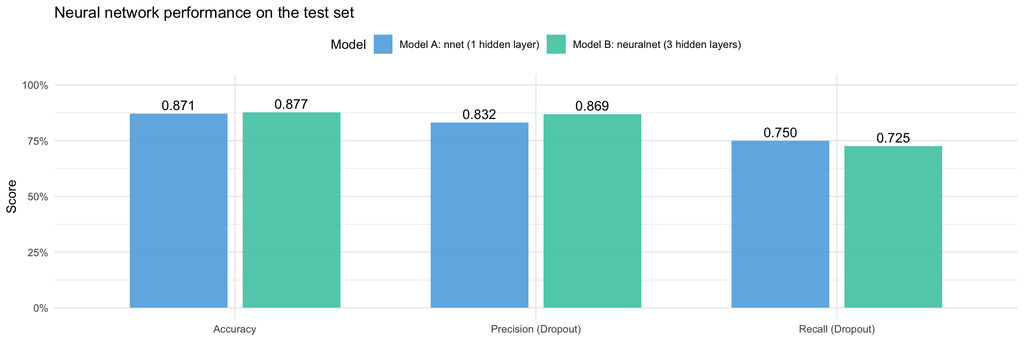

```r
metrics_long <- metrics_df %>%
  pivot_longer(cols = c(Accuracy, Precision, Recall), names_to = "Metric", values_to = "Value") %>%
  mutate(
    Metric = recode(
      Metric,
      Accuracy = "Accuracy",
      Precision = "Precision (Dropout)",
      Recall = "Recall (Dropout)"
    )
  )

ggplot(metrics_long, aes(x = Metric, y = Value, fill = Model)) +
  geom_col(position = position_dodge(width = 0.75), width = 0.65, alpha = 0.9) +
  geom_text(
    aes(label = sprintf("%.3f", Value)),
    position = position_dodge(width = 0.75),
    vjust = -0.4,
    size = 4
  ) +
  scale_y_continuous(limits = c(0, 1), labels = scales::percent_format(accuracy = 1)) +
  scale_fill_manual(values = c("#5DADE2", "#48C9B0")) +
  labs(
    title = "Neural network performance on the test set",
    x = NULL,
    y = "Score",
    fill = "Model"
  ) +
  theme_minimal() +
  theme(legend.position = "top")
```

## Confusion Matrix Comparison

Side-by-side heatmaps comparing both models. X-axis (top) = Predicted, Y-axis = True labels.

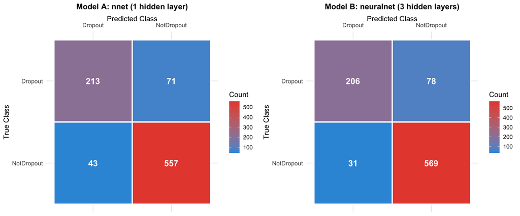

```r
# Helper function to create confusion matrix plot
# Rows = True values (y-axis), Columns = Predicted values (x-axis on top)
plot_confusion_matrix <- function(conf_matrix, title) {
  cm_df <- as.data.frame(conf_matrix$table)
  # confusionMatrix table: rows = Prediction, cols = Reference (True)
  names(cm_df) <- c("Predicted", "True", "Count")

  ggplot(cm_df, aes(x = Predicted, y = True, fill = Count)) +
    geom_tile(color = "white", linewidth = 1) +
    geom_text(aes(label = Count), size = 5, fontface = "bold", color = "white") +
    scale_fill_gradient(low = "#3498DB", high = "#E74C3C", name = "Count") +
    scale_x_discrete(position = "top") +
    scale_y_discrete(limits = rev(c("Dropout", "NotDropout"))) +
    labs(title = title, x = "Predicted Class", y = "True Class") +
    theme_minimal(base_size = 12) +
    theme(
      plot.title = element_text(hjust = 0.5, face = "bold", size = 13),
      axis.text = element_text(size = 10),
      legend.position = "right"
    )
}

# Create plots for both models
plot_A <- plot_confusion_matrix(conf_matrix_A, "Model A: nnet (1 hidden layer)")
plot_B <- plot_confusion_matrix(conf_matrix_B, "Model B: neuralnet (3 hidden layers)")

# Display side by side
grid.arrange(plot_A, plot_B, ncol = 2)
```

## ROC Curve Comparison

We compare ROC curves for **Dropout** (Dropout vs NotDropout) across both models using `ROCR`.

```r
# --- Model A ROC (nnet) ---
prob_A <- predict(model_A, newdata = test_nn, type = "raw")

# Safety: nnet with binary target outputs P(Class 2), which is NotDropout.
# We need P(Dropout).
if (is.null(dim(prob_A)) || ncol(prob_A) == 1) {
  # Single column output = P(NotDropout) because NotDropout is the 2nd level
  prob_A_drop <- 1 - as.numeric(prob_A)
} else if ("Dropout" %in% colnames(prob_A)) {
  # If it somehow returns multiple columns (e.g. if we forced softmax successfully)
  prob_A_drop <- prob_A[, "Dropout"]
} else {
  # Fallback: assume first column is Dropout if multiple exist
  prob_A_drop <- prob_A[, 1]
}

pred_A_drop <- ROCR::prediction(prob_A_drop, test_nn$Target == "Dropout")
perf_A_drop <- ROCR::performance(pred_A_drop, "tpr", "fpr")
auc_A <- round(ROCR::performance(pred_A_drop, "auc")@y.values[[1]], 3)

# --- Model B ROC (neuralnet) ---
# Dropout is the 1st output column in pred_B_raw
if (is.null(dim(pred_B_raw))) {
  prob_B_drop <- as.numeric(pred_B_raw)
} else {
  prob_B_drop <- pred_B_raw[, 1]
}
pred_B_drop <- ROCR::prediction(prob_B_drop, test_nn$Target == "Dropout")
perf_B_drop <- ROCR::performance(pred_B_drop, "tpr", "fpr")
auc_B <- round(ROCR::performance(pred_B_drop, "auc")@y.values[[1]], 3)
```

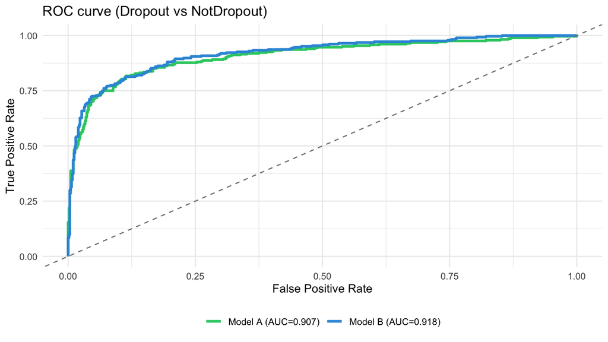

```r
roc_A_df <- data.frame(
  FPR = perf_A_drop@x.values[[1]],
  TPR = perf_A_drop@y.values[[1]],
  Model = sprintf("Model A (AUC=%.3f)", auc_A)
)
roc_B_df <- data.frame(
  FPR = perf_B_drop@x.values[[1]],
  TPR = perf_B_drop@y.values[[1]],
  Model = sprintf("Model B (AUC=%.3f)", auc_B)
)
roc_df <- bind_rows(roc_A_df, roc_B_df)

ggplot(roc_df, aes(x = FPR, y = TPR, color = Model)) +
  geom_line(linewidth = 1.2) +
  geom_abline(slope = 1, intercept = 0, linetype = 2, color = "gray50") +
  scale_color_manual(values = c("#2ecc71", "#3498db")) +
  labs(
    title = "ROC curve (Dropout vs NotDropout)",
    x = "False Positive Rate",
    y = "True Positive Rate",
    color = NULL
  ) +
  theme_minimal() +
  theme(legend.position = "bottom")
```

**AUC interpretation:** higher AUC means better separation of Dropout vs NotDropout. Here, Model A has AUC **0.907** and Model B has AUC **0.918**.

## Feature Importance (Permutation)

Permutation importance (same spirit as Lab 1’s “what-if” checks) measures how much each model’s accuracy drops when we randomly shuffle one predictor at a time. Bigger drops mean the learner relied heavily on that feature.

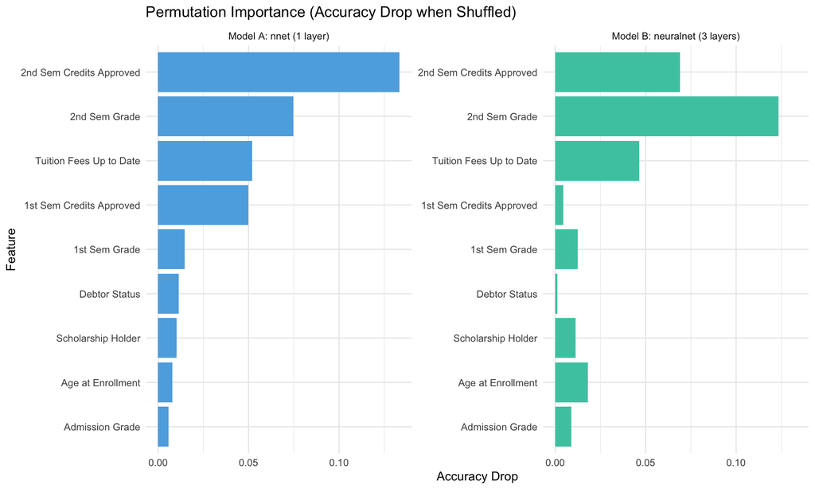

```r
# Helper to compute accuracy drop for a single feature and model
permute_feature <- function(model_type, var_name) {
  permuted <- test_nn
  permuted[[var_name]] <- sample(permuted[[var_name]])

  if (model_type == "Model A: nnet (1 layer)") {
    baseline <- mean(predict(model_A, newdata = test_nn, type = "class") == test_nn$Target)
    perm_acc <- mean(predict(model_A, newdata = permuted, type = "class") == test_nn$Target)
  } else {
    # Rebuild dummy matrix for permuted data
    permuted_matrix <- as.data.frame(predict(dummies, newdata = permuted))
    permuted_matrix[] <- lapply(permuted_matrix, as.numeric)
    class_map <- c("Dropout", "NotDropout")
    baseline <- mean(pred_B_class == test_nn$Target)
    perm_raw <- compute(model_B, as.matrix(permuted_matrix[, input_names]))$net.result
    perm_class <- factor(class_map[apply(perm_raw, 1, which.max)], levels = class_map)
    perm_acc <- mean(perm_class == test_nn$Target)
  }

  tibble(
    Model = model_type,
    Feature = var_name,
    AccuracyDrop = baseline - perm_acc
  )
}

perm_results <- map_dfr(
  nn_features,
  ~bind_rows(
    permute_feature("Model A: nnet (1 layer)", .x),
    permute_feature("Model B: neuralnet (3 layers)", .x)
  )
)

# Friendlier labels for the plot
feature_labels <- c(
  "Curricular.units.1st.sem..approved." = "1st Sem Credits Approved",
  "Curricular.units.1st.sem..grade." = "1st Sem Grade",
  "Curricular.units.2nd.sem..approved." = "2nd Sem Credits Approved",
  "Curricular.units.2nd.sem..grade." = "2nd Sem Grade",
  "Tuition.fees.up.to.date" = "Tuition Fees Up to Date",
  "Scholarship.holder" = "Scholarship Holder",
  "Age.at.enrollment" = "Age at Enrollment",
  "Admission.grade" = "Admission Grade",
  "Debtor" = "Debtor Status"
)

perm_results <- perm_results %>%
  mutate(Feature = recode(Feature, !!!feature_labels)) %>%
  group_by(Model) %>%
  mutate(Feature = fct_reorder(Feature, AccuracyDrop)) %>%
  ungroup()

ggplot(perm_results, aes(x = AccuracyDrop, y = Feature, fill = Model)) +
  geom_col(show.legend = FALSE) +
  facet_wrap(~Model, scales = "free_y") +
  labs(
    title = "Permutation Importance (Accuracy Drop when Shuffled)",
    x = "Accuracy Drop",
    y = "Feature"
  ) +
  scale_fill_manual(values = c("#5DADE2", "#48C9B0")) +
  theme_minimal()
```

```r
perm_top <- perm_results %>%
  group_by(Model) %>%
  slice_max(order_by = AccuracyDrop, n = 5, with_ties = FALSE) %>%
  ungroup() %>%
  mutate(AccuracyDropPctPoints = round(AccuracyDrop * 100, 2)) %>%
  select(Model, Feature, AccuracyDropPctPoints)

knitr::kable(
  perm_top,
  caption = "Top 5 permutation importances (how many accuracy percentage points we lose when we shuffle the feature)"
)
```

Top 5 permutation importances (how many accuracy percentage points we lose when we shuffle the feature)

| Model | Feature | AccuracyDropPctPoints |
| --- | --- | --- |
| Model A: nnet (1 layer) | 2nd Sem Credits Approved | 13.35 |
| Model A: nnet (1 layer) | 2nd Sem Grade | 7.47 |
| Model A: nnet (1 layer) | Tuition Fees Up to Date | 5.20 |
| Model A: nnet (1 layer) | 1st Sem Credits Approved | 4.98 |
| Model A: nnet (1 layer) | 1st Sem Grade | 1.47 |
| Model B: neuralnet (3 layers) | 2nd Sem Grade | 12.33 |
| Model B: neuralnet (3 layers) | 2nd Sem Credits Approved | 6.90 |
| Model B: neuralnet (3 layers) | Tuition Fees Up to Date | 4.64 |
| Model B: neuralnet (3 layers) | Age at Enrollment | 1.81 |
| Model B: neuralnet (3 layers) | 1st Sem Grade | 1.24 |

## Business Use: Early Warning and Intervention

This neural network can be used as an **early warning system**:

1. At the end of the 1st/2nd semester, we collect the same inputs (grades, approved units, tuition status, scholarship, debtor status).
2. The model outputs a **dropout risk score** for each student.
3. The university can then target limited support resources to students with the highest predicted risk.

Examples of interventions (linked to our most important features):

- **Academic performance signals (grades, approved units):** provide tutoring, mentoring, and early academic advising.
- **Financial stress signals (tuition up to date, debtor):** proactive outreach about payment plans and financial aid options.
- **Support signals (scholarship holder):** consider expanding support programs for similar students who are not currently covered.

Important caution (beginner-friendly):

- The model helps us **prioritize** students for support, but it should not be the only decision tool.
- The safest process is to combine model predictions with human review (advisors) before taking action.

## Neural Network Architecture Visualization

`NeuralNetTools::plotnet()` turns the fitted networks into diagrams that show layers, neurons, and connection strengths (thicker lines = larger absolute weights). Seeing both side by side links back to Lab 2’s focus on architecture design.

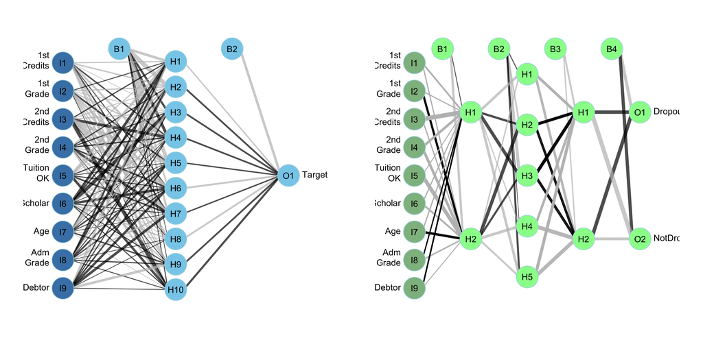

```r
# Labels include line breaks so they fit without changing plot size
short_labels <- c("1st\nCredits", "1st\nGrade", "2nd\nCredits", "2nd\nGrade",
                  "Tuition\nOK", "Scholar", "Age", "Adm\nGrade", "Debtor")
output_labels_B <- c("Dropout", "NotDropout")  # Model B has 2 output neurons

par(mfrow = c(1, 2), mar = c(2, 2, 2, 2))
NeuralNetTools::plotnet(
  model_A,
  alpha = 0.7,
  circle_col = list("steelblue", "skyblue"),
  x_names = short_labels,
  # y_names omitted for Model A (1 output)
  max_sp = TRUE,
  cex_val = 0.9,
  line_lwd = 0.8
)
NeuralNetTools::plotnet(
  model_B,
  alpha = 0.7,
  circle_col = list("darkseagreen", "palegreen"),
  x_names = short_labels,
  y_names = output_labels_B,
  max_sp = TRUE,
  cex_val = 0.9,
  line_lwd = 0.8
)
```

```r
par(mfrow = c(1, 1))
```

## Findings & Interpretation

**Model A (nnet):** 9 inputs - 10 hidden neurons - 1 output (P(NotDropout)). Simple, fast, handles factors directly and reaches strong test performance.

**Model B (neuralnet):** 9 inputs - 2 - 5 - 2 neurons - 2 outputs. Shows Lab 2’s deeper setup but still does not automatically outperform the simpler Model A.

**Strengths observed:** Neural networks capture non-linear interaction between grades, tuition status, and scholarships.

**Limitations observed:**

- Deeper networks remain sensitive to hyperparameters and can overfit small samples.
- Interpretability is limited compared to GLM/GAM coefficients.
- Because we combine **Enrolled + Graduate** into **NotDropout**, this target cannot distinguish “still studying” from “already graduated”. This is acceptable for an early-warning dropout use case, but it matters if the business question is specifically “who will graduate”.

## Conclusions

**Recommendation:** if not enough space in report, Keep Model A as the primary neural network in this case, and mention Model B as an exploratory Lab 2 extension